# Choosing a Medicare Advantage Plan By Looking at Star Measures

# Overview and Motivation

### Motivation

We all want our parents and loved ones to recieve the best medical coverage possible. My parents are 2 years away from Medicare eligibility, and I want to take a data driven approach to finding which health insurance organizations provide the best service by analyzing Star Ratings Measurements. Medicare Part C is a program administered by the Center for Medicare and Medicaid Services (CMS) that combines Medicare Parts A and B (traditional Medicare) and optionally Part D (Prescription Drug Plan) through which beneficiaries recieve coverage through private insurance companies (United, Aetna, Humana, etc.) These insurance companies often offer greater benefits than what is offered through traditional Medicare, so it can be appealing to certain people based on their coverage needs. Enrollment in Medicare Part C has increased every year since 2005 and currently, approximately 34% of Medicare Benficiaries get their coverage through Part C[^1]

### Overview

CMS assigns the insurance contracts Category Star Ratings between 1-5 for various categories such as “Staying Healthy: Screenings, Tests and Vaccines” and “Managing Chronic (Long Term) Conditions.” These categories are aggregated up to give a plan one final Star Rating. These insurance companies deeply care about having a higher Star Rating because they are rewarded lucrative benefits such as increased revenue and a longer enrollment period. Each of the Category Star Ratings is determined by sub-measures such as “Colorectal Cancer Screening,” “Controlling Blood Pressure,” and “Rheumatoid Arthritis Management.”

It is these sub-measures that we will be analyzing because it is precisely these sub-measures which can give us insight into how these plans are performing.

# Initial Questions

There are three main questions that we want to tackle:

- Are there certain insurance companies that perform better among certain measures? Which companies and which measures?
- Does the size of the enrollment in the contract play an impact in measures?
- For a person with specific needs due to a chronic condition, which plan features and/or organizations are the best choice to manage that condition?

# Data

There are three main data sets we are going to be pulling from:

- Enrollment information for Medicare Part C plans
- Contract information for Medicare Part C plans
- Star Rating data for Medicare Part C plans.

All of these data are publicly available through the CMS website[^2]. Initially the data seemed extremely messy with lots of missing values, but after a thorough investigation of the data it became much clearer. There are lots of smaller organizations with small and/or new contracts, and thus, the reporting requirements are more lenient. However, if we only consider contracts with >10,000 total enrollment and exclude certain specific plans (Demos and employer specific) the data is much cleaner while still covering 95% of total enrollment. Ultimately, when it comes to dealing with missing data, something has to give and unless you can develop imputation methods (impossible in this circumstance) we have to take what we are given. Furthermore, missing a few small/obscure contracts will not change the nature of the information, as this nice pie-chart from the Kaiser Family Foundation shows market dominance by the major players:

[figure not shown]

### Data Importing and Joining.

Cleaning and organizing the data was the majority of the work. We had to recode a few values, perform some joins to get all the data together, and clean up values that were not reported and present them as NA so that R could digest them appropriately. Numeric data was mixed with character data, and there was several different markers more missing data. Most of the cleaning is actually done in the Analysis section because it was more prudent to clean the data on an ad hoc basis depending on which analysis we were trying to perform, and also maintaining the most data we can.

# Data Analysis

Manual inspection of the measures taken help us focus in on the specific questions we want to answer. To cover a broad range of categories/questions we will consider the following measures:

### **Measure of overall effectiveness**

- **Members Choosing to Leave the Plan:** This is not a perfect measure, as some areas have less plans operating in them, but seeing as how traditional Medicare is always an option, this measure should give information of how satisfied plan beneficiaries are.
- **Rating of Health Care Quality:** It is obvious why this is important.
- **Rating of Health Plan:** It is obvious why this is important.
- **Getting Needed Care:** Again, obvious why it’s important.

### **Measures for Diabetes Care**

- **Diabetes Care - Eye Exam**
- **Diabetes Care - Blood Sugar Controlled**
- **Medication Adherence for Diabetes Medications.** Note this is only relevent for contracts offering Part D plans.

### **Measures Preventative Health/Screening**

- **Breast Cancer Screening**
- **Colorectal Cancer Screening**
- **Adult BMI Assessment**

We will also asses the **Plan Type, Plan Size,** and **Parent Organization** to see if these factors have an effect.

Let us first explore the effect of plan type on overal plan effectiveness by looking at how they perform differently among the **Measures of Overall effectiveness** as noted above.

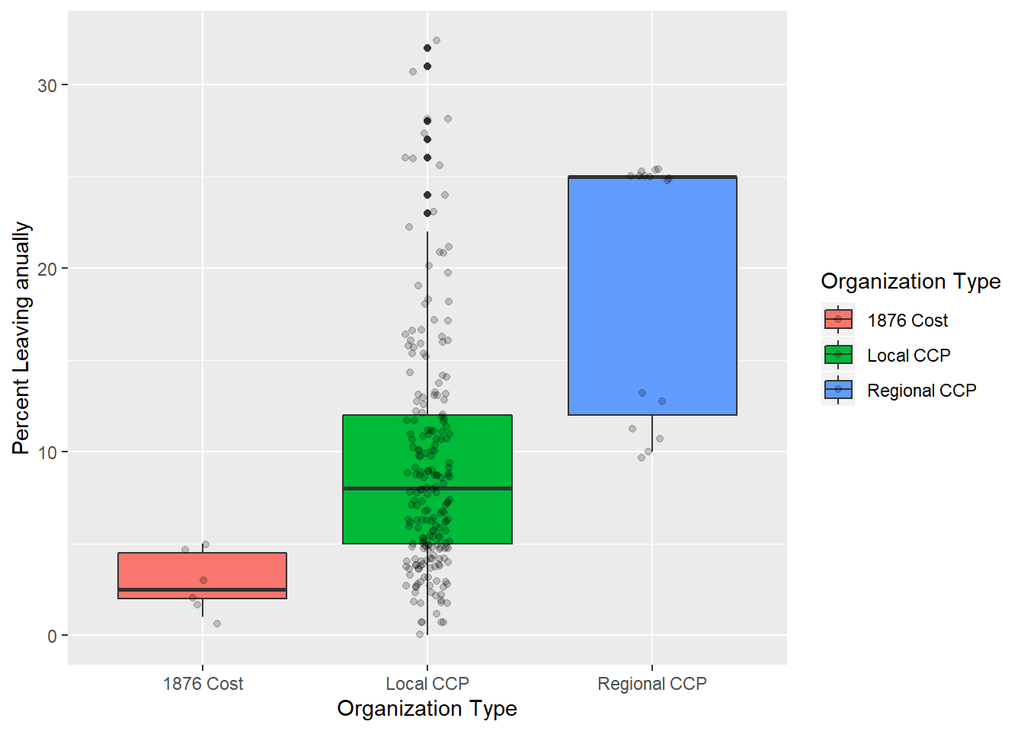

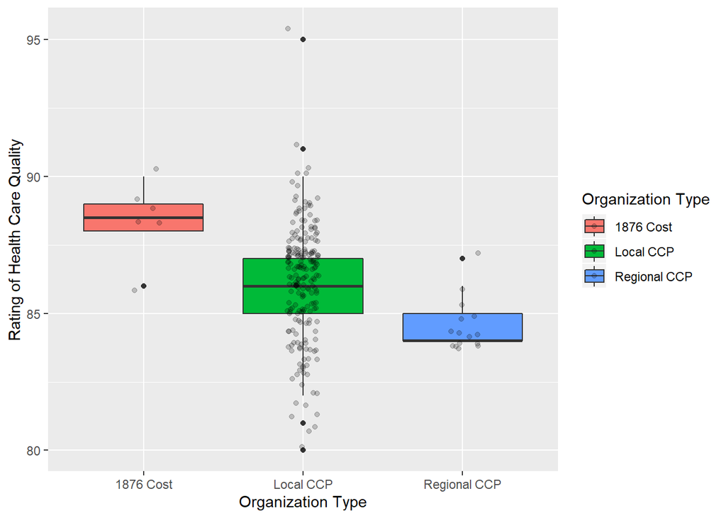

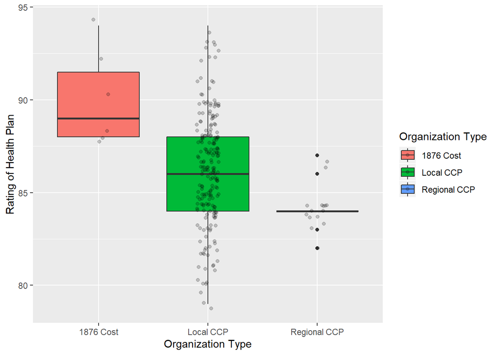

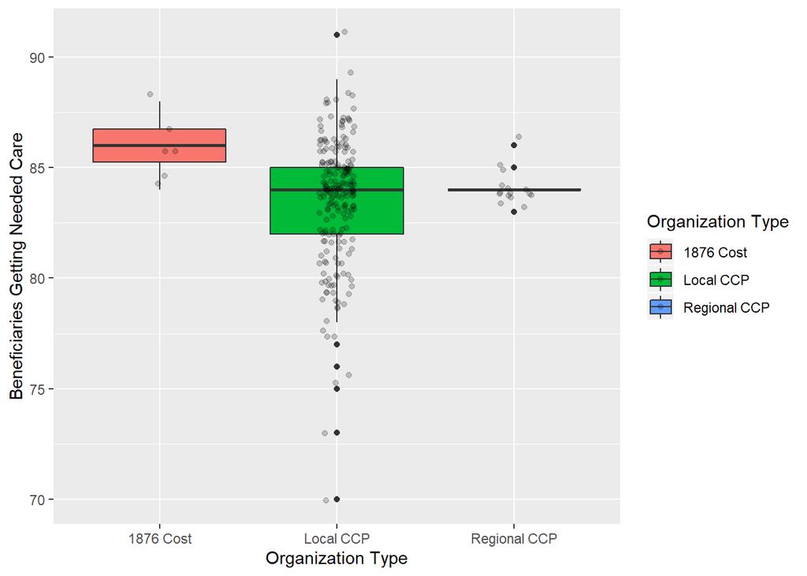

Next, to look at the diabetes measures, we regress the diabetes measures on the age of the plan in years and the log of the total enrollment of the plan. The images shown below plot logged enrollment against the measures. The p-values for all the regression coeffecients except for one (p=.053) are statistically significant at the .05 level.

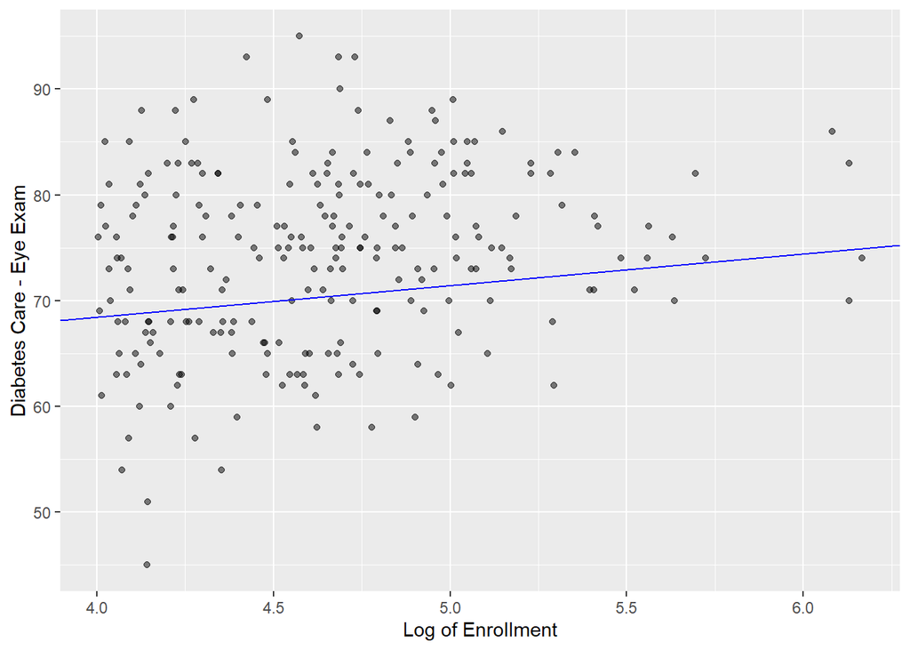

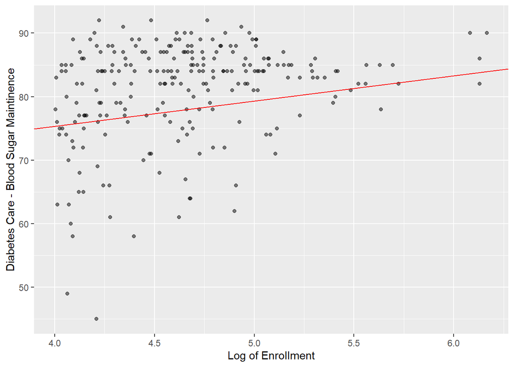

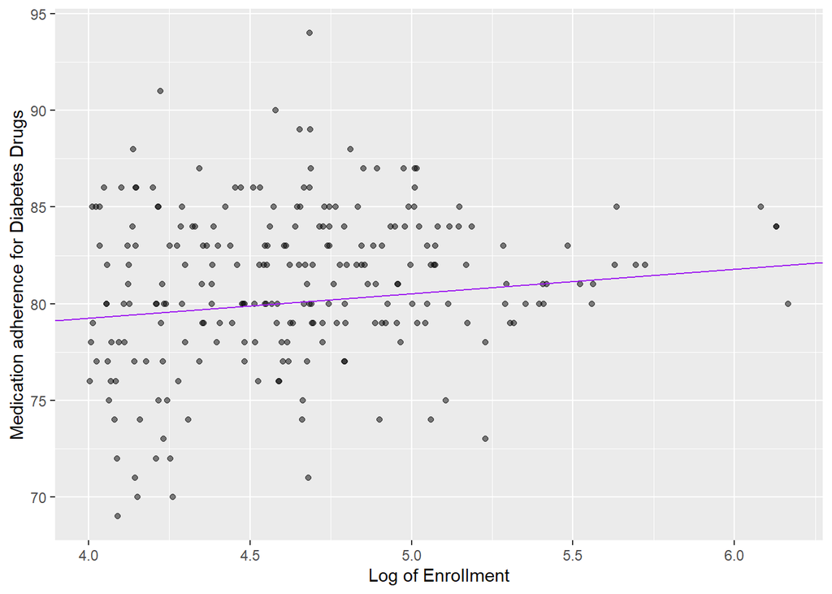

Based on the coefficients of the covariates and their p values we can say that generally a larger and older Medicare Contract will provide better diabetes care.